```python
import os
import numpy as np
import pandas as pd
import matplotlib.pyplot as plt
import statsmodels.api as sm
from patsy import dmatrix
from sklearn.model_selection import KFold
from sklearn.metrics import mean_squared_error

pd.set_option('display.precision', 3)
```

# PSL: Regression Splines

# Week 4 Example (Fall 2025)

## The Birthrate Data Set

The Birthrate data set contains U.S. birth rate data from 1917 to 2003.

```python
birthrates = pd.read_csv("birthrates.csv")
print(birthrates.head())
```

```
   Year  Birthrate
0  1917      183.1
1  1918      183.9
2  1919      163.1
3  1920      179.5
4  1921      181.4
```

Plotting the data we have

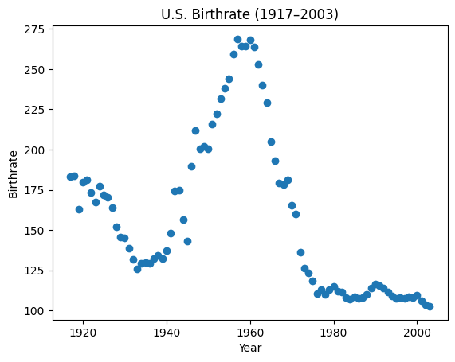

```python
plt.figure()
plt.scatter(birthrates['Year'], birthrates['Birthrate'])
plt.xlabel('Year'); plt.ylabel('Birthrate')
plt.title('U.S. Birthrate (1917–2003)')
plt.show()
```

which is an highly nonlinear trend.

We first try to fit a polynomial regression with orthogonal polynomials for polynomials with degrees 3, and 6. The fitted lines can be shown below:

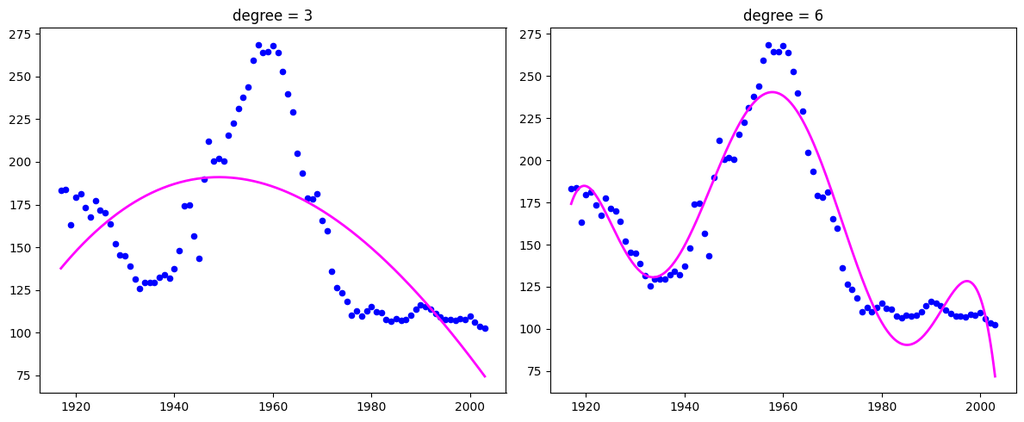

```python
X = birthrates["Year"]
y = birthrates["Birthrate"]

def fit_orthopoly(x, y, degree):
    X_poly = np.polynomial.legendre.legvander(
        np.interp(x, (x.min(), x.max()), (-1, 1)), degree
    )
    model = sm.OLS(y, X_poly).fit()

    x_grid = np.linspace(x.min(), x.max(), 300)
    x_scaled = np.interp(x_grid, (x.min(), x.max()), (-1, 1))
    X_grid_poly = np.polynomial.legendre.legvander(x_scaled, degree)
    y_pred = model.predict(X_grid_poly)
    return x_grid, y_pred

x3, y3 = fit_orthopoly(X, y, 3)

x6, y6 = fit_orthopoly(X, y, 6)

fig, axes = plt.subplots(1, 2, figsize=(12, 5))

axes[0].scatter(X, y, color="blue", s=20)
axes[0].plot(x3, y3, color="magenta", linewidth=2)
axes[0].set_title("degree = 3")

axes[1].scatter(X, y, color="blue", s=20)
axes[1].plot(x6, y6, color="magenta", linewidth=2)
axes[1].set_title("degree = 6")

plt.tight_layout()
plt.show()
```

We can see that the 6th order polynomial is better, but it is not very good. We can try fitting local polynomials - piecewise polynomials of lower order (we try constant functions and linear function in the example below:

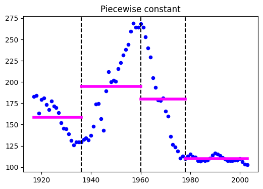

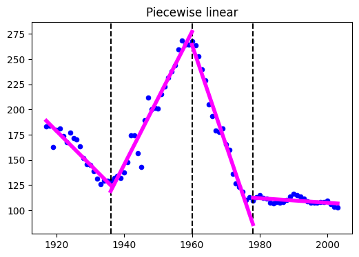

```python
years = birthrates["Year"].values
rates = birthrates["Birthrate"].values

myknots = [1936, 1960, 1978]
bounds = [1917] + myknots + [2003]

X_const = np.column_stack([
    (years < myknots[0]),
    (years >= myknots[0]) & (years < myknots[1]),
    (years >= myknots[1]) & (years < myknots[2]),
    (years >= myknots[2])
]).astype(int)

const_model = sm.OLS(rates, X_const).fit()

plt.figure(figsize=(6,4))
plt.scatter(years, rates, color="blue", s=20)
for knot in myknots:
    plt.axvline(knot, linestyle="--", color="black")

for k in range(4):
    plt.plot(
        [bounds[k], bounds[k+1]],
        [const_model.params[k]]*2,
        color="magenta", linewidth=4
    )

plt.title("Piecewise constant")
plt.show()

X_linear = np.column_stack([
    (years < myknots[0]),
    (years >= myknots[0]) & (years < myknots[1]),
    (years >= myknots[1]) & (years < myknots[2]),
    (years >= myknots[2]),
    years*(years < myknots[0]),
    years*((years >= myknots[0]) & (years < myknots[1])),
    years*((years >= myknots[1]) & (years < myknots[2])),
    years*(years >= myknots[2])
]).astype(float)

line_model = sm.OLS(rates, X_linear).fit()

plt.figure(figsize=(6,4))
plt.scatter(years, rates, color="blue", s=20)
for knot in myknots:
    plt.axvline(knot, linestyle="--", color="black")

for k in range(4):
    plt.plot(
        [bounds[k], bounds[k+1]],
        line_model.params[k] + np.array([bounds[k], bounds[k+1]]) * line_model.params[k+4],
        color="magenta", linewidth=4
    )

plt.title("Piecewise linear")
plt.show()
```

As we discussed in the lecture, it is a localized fit, but there are discontinuities and the overall fit is not good.

### Splines Regression

Instead, we can use **splines** to fit the data. Let us first try to use the B-Splines. We will first try a **linear spline**

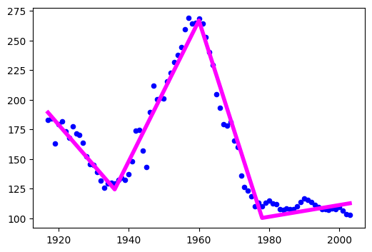

```python
X_bs = dmatrix("bs(year, knots=(1936,1960,1978), degree=1, include_intercept=True)",
               {"year": birthrates["Year"]}, return_type='dataframe')

model_bs = sm.OLS(birthrates["Birthrate"], X_bs).fit()

fitted = model_bs.fittedvalues

plt.figure(figsize=(6,4))
plt.scatter(birthrates["Year"], birthrates["Birthrate"], color="blue", s=20)
plt.plot(birthrates["Year"], fitted, color="magenta", linewidth=4)
plt.show()
```

and then a **cubic spline** (as the ones discussed in class)

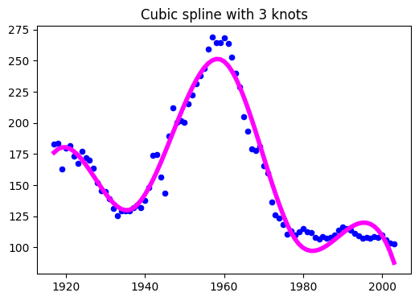

```python
X_bs3 = dmatrix("bs(year, knots=(1936,1960,1978), degree=3, include_intercept=True)",
                {"year": birthrates["Year"]}, return_type='dataframe')

model_bs3 = sm.OLS(birthrates["Birthrate"], X_bs3).fit()

fitted3 = model_bs3.fittedvalues

plt.figure(figsize=(6,4))
plt.scatter(birthrates["Year"], birthrates["Birthrate"], color="blue", s=20)
plt.plot(birthrates["Year"], fitted3, color="magenta", linewidth=4)
plt.title("Cubic spline with 3 knots")
plt.show()
```

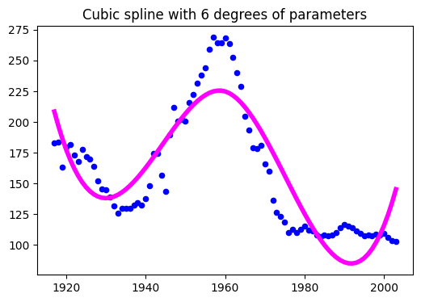

```python
X_bs_df5 = dmatrix("bs(year, df=5, degree=3, include_intercept=True)",
                   {"year": birthrates["Year"]}, return_type='dataframe')

model_bs_df5 = sm.OLS(birthrates["Birthrate"], X_bs_df5).fit()

fitted_df5 = model_bs_df5.fittedvalues

plt.figure(figsize=(6,4))
plt.scatter(birthrates["Year"], birthrates["Birthrate"], color="blue", s=20)
plt.plot(birthrates["Year"], fitted_df5, color="magenta", linewidth=4)
plt.title("Cubic spline with 6 degrees of parameters")
plt.show()
```

Let us now try the **Natural Cubic Splines**

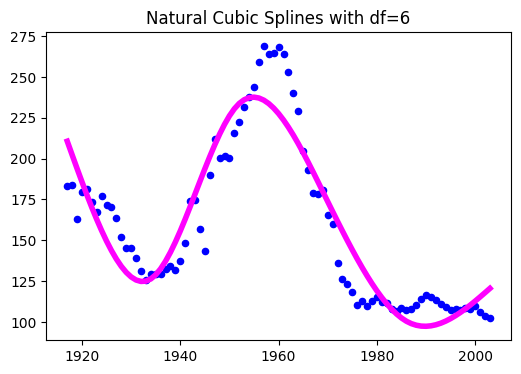

```python
years = birthrates["Year"].values
rates = birthrates["Birthrate"].values

X_ns = dmatrix("cr(year, df=6, lower_bound=1917, upper_bound=2003)",
               {"year": years}, return_type='dataframe')

model_ns = sm.OLS(rates, X_ns).fit()
fitted = model_ns.fittedvalues

order = np.argsort(years)

plt.figure(figsize=(6,4))
plt.scatter(years, rates, color="blue", s=20)
plt.plot(years[order], fitted.values[order], color="magenta", linewidth=4)
plt.title("Natural Cubic Splines with df=6")
plt.show()
```

Comment: Python uses a different algorithm for the Natural Cubic Splines compared to R, so the results we get might not be the same.